# W3cubDocs

/scikit-learn

# 2.5. Decomposing signals in components (matrix factorization problems)

## 2.5.1. Principal component analysis (PCA)

### 2.5.1.1. Exact PCA and probabilistic interpretation

PCA is used to decompose a multivariate dataset in a set of successive orthogonal components that explain a maximum amount of the variance. In scikit-learn, `PCA` is implemented as a *transformer* object that learns $n$ components in its `fit` method, and can be used on new data to project it on these components.

The optional parameter `whiten=True` makes it possible to project the data onto the singular space while scaling each component to unit variance. This is often useful if the models down-stream make strong assumptions on the isotropy of the signal: this is for example the case for Support Vector Machines with the RBF kernel and the K-Means clustering algorithm.

Below is an example of the iris dataset, which is comprised of 4 features, projected on the 2 dimensions that explain most variance:

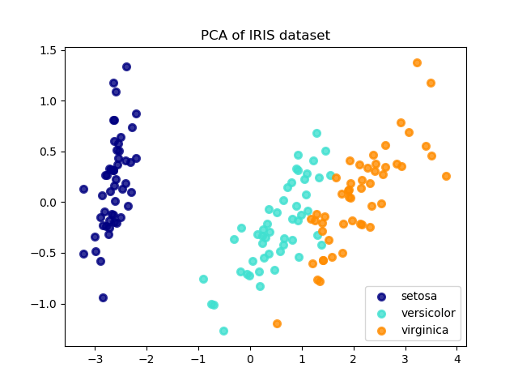

The `PCA` object also provides a probabilistic interpretation of the PCA that can give a likelihood of data based on the amount of variance it explains. As such it implements a `score` method that can be used in cross-validation:

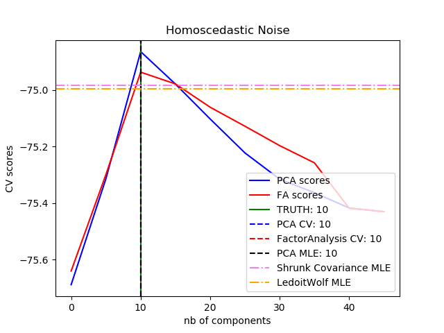

Examples:

- Comparison of LDA and PCA 2D projection of Iris dataset
- Model selection with Probabilistic PCA and Factor Analysis (FA)

### 2.5.1.2. Incremental PCA

The `PCA` object is very useful, but has certain limitations for large datasets. The biggest limitation is that `PCA` only supports batch processing, which means all of the data to be processed must fit in main memory. The `IncrementalPCA` object uses a different form of processing and allows for partial computations which almost exactly match the results of `PCA` while processing the data in a minibatch fashion. `IncrementalPCA` makes it possible to implement out-of-core Principal Component Analysis either by:

- Using its `partial_fit` method on chunks of data fetched sequentially from the local hard drive or a network database.
- Calling its fit method on a memory mapped file using `numpy.memmap`.

`IncrementalPCA` only stores estimates of component and noise variances, in order update `explained_variance_ratio_` incrementally. This is why memory usage depends on the number of samples per batch, rather than the number of samples to be processed in the dataset.

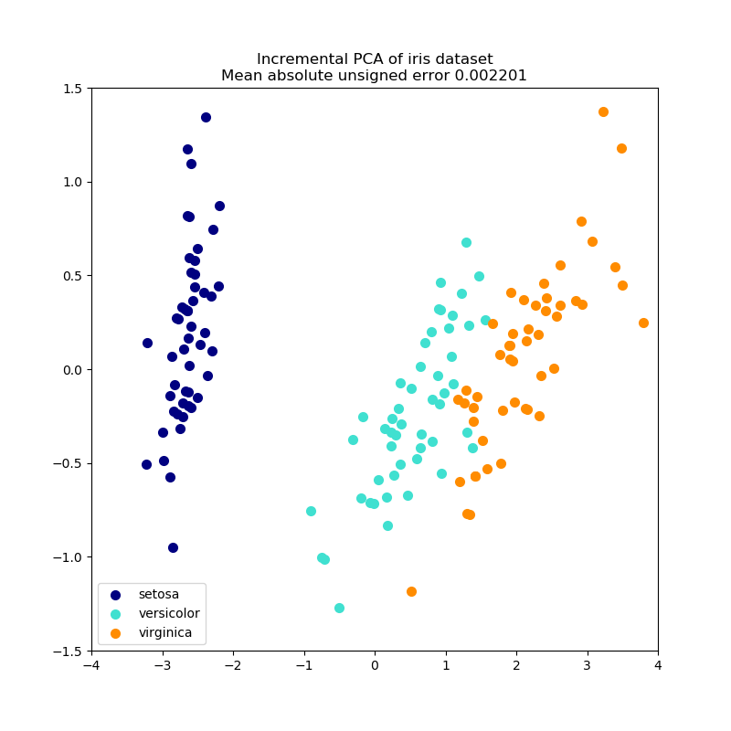

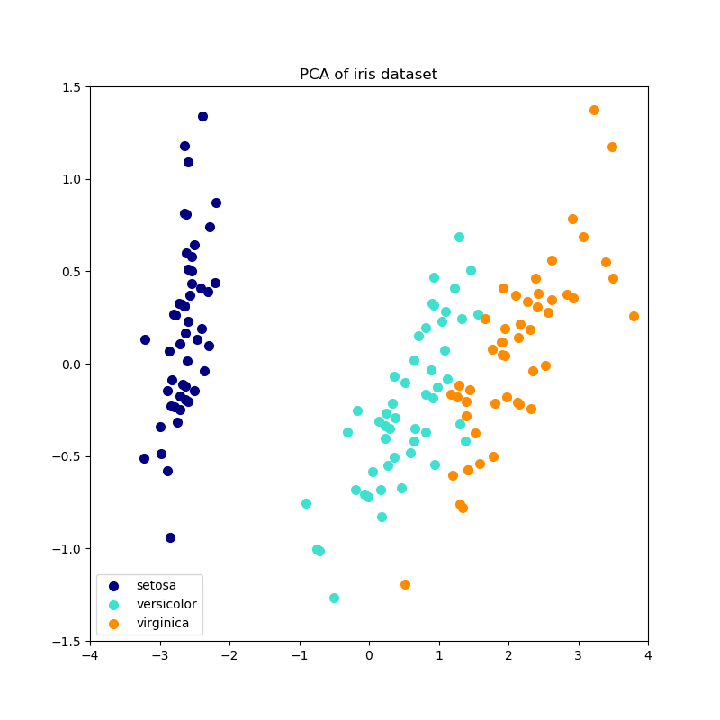

Examples:

- Incremental PCA

### 2.5.1.3. PCA using randomized SVD

It is often interesting to project data to a lower-dimensional space that preserves most of the variance, by dropping the singular vector of components associated with lower singular values.

For instance, if we work with 64x64 pixel gray-level pictures for face recognition, the dimensionality of the data is 4096 and it is slow to train an RBF support vector machine on such wide data. Furthermore we know that the intrinsic dimensionality of the data is much lower than 4096 since all pictures of human faces look somewhat alike. The samples lie on a manifold of much lower dimension (say around 200 for instance). The PCA algorithm can be used to linearly transform the data while both reducing the dimensionality and preserve most of the explained variance at the same time.

The class `PCA` used with the optional parameter `svd_solver='randomized'` is very useful in that case: since we are going to drop most of the singular vectors it is much more efficient to limit the computation to an approximated estimate of the singular vectors we will keep to actually perform the transform.

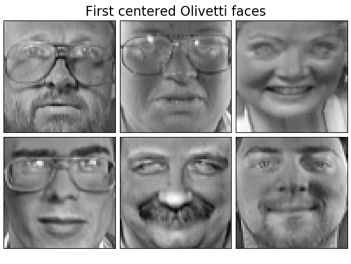

Note: with the optional parameter `svd_solver='randomized'`, we also need to give `PCA` the size of the lower-dimensional space `n_components` as a mandatory input parameter.

If we note $n_{\max} = \max(n_{\mathrm{samples}}, n_{\mathrm{features}})$ and $n_{\min} = \min(n_{\mathrm{samples}}, n_{\mathrm{features}})$, the time complexity of the randomized `PCA` is $O(n_{\max}^2 \cdot n_{\mathrm{components}})$ instead of $O(n_{\max}^2 \cdot n_{\min})$ for the exact method implemented in `PCA`.

The memory footprint of randomized `PCA` is also proportional to $2 \cdot n_{\max} \cdot n_{\mathrm{components}}$ instead of $n_{\max} \cdot n_{\min}$ for the exact method.

Note: the implementation of `inverse_transform` in `PCA` with `svd_solver='randomized'` is not the exact inverse transform of `transform` even when `whiten=False` (default).

Examples:

- Faces recognition example using eigenfaces and SVMs
- Faces dataset decompositions

References:

- [“Finding structure with randomness: Stochastic algorithms for constructing approximate matrix decompositions”](http://arxiv.org/abs/0909.4061) Halko, et al., 2009

### 2.5.1.4. Kernel PCA

`KernelPCA` is an extension of PCA which achieves non-linear dimensionality reduction through the use of kernels (see Pairwise metrics, Affinities and Kernels). It has many applications including denoising, compression and structured prediction (kernel dependency estimation). `KernelPCA` supports both `transform` and `inverse_transform`.

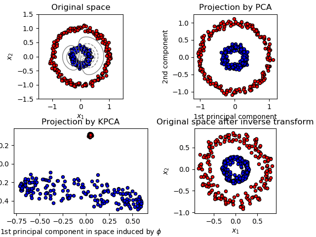

Examples:

- Kernel PCA

### 2.5.1.5. Sparse principal components analysis (SparsePCA and MiniBatchSparsePCA)

`SparsePCA` is a variant of PCA, with the goal of extracting the set of sparse components that best reconstruct the data.

Mini-batch sparse PCA (`MiniBatchSparsePCA`) is a variant of `SparsePCA` that is faster but less accurate. The increased speed is reached by iterating over small chunks of the set of features, for a given number of iterations.

Principal component analysis (`PCA`) has the disadvantage that the components extracted by this method have exclusively dense expressions, i.e. they have non-zero coefficients when expressed as linear combinations of the original variables. This can make interpretation difficult. In many cases, the real underlying components can be more naturally imagined as sparse vectors; for example in face recognition, components might naturally map to parts of faces.

Sparse principal components yields a more parsimonious, interpretable representation, clearly emphasizing which of the original features contribute to the differences between samples.

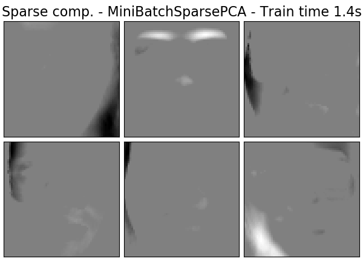

Note that there are many different formulations for the Sparse PCA problem. The one implemented here is based on [Mrl09] . The optimization problem solved is a PCA problem (dictionary learning) with an $\ell_1$ penalty on the components:

$\begin{split}(U^*, V^*) = \underset{U, V}{\operatorname{arg\,min\,}} & \frac{1}{2} ||X-UV||_2^2+\alpha||V||_1 \\ \text{subject to } & ||U_k||_2 = 1 \text{ for all } 0 \leq k < n_{components}\end{split}$

The sparsity-inducing $\ell_1$ norm also prevents learning components from noise when few training samples are available. The degree of penalization (and thus sparsity) can be adjusted through the hyperparameter `alpha`. Small values lead to a gently regularized factorization, while larger values shrink many coefficients to zero.

Note

While in the spirit of an online algorithm, the class `MiniBatchSparsePCA` does not implement `partial_fit` because the algorithm is online along the features direction, not the samples direction.

Examples:

- Faces dataset decompositions

References:

| [Mrl09] | [“Online Dictionary Learning for Sparse Coding”](http://www.di.ens.fr/sierra/pdfs/icml09.pdf) J. Mairal, F. Bach, J. Ponce, G. Sapiro, 2009 |
| --- | --- |

| [Jen09] | “Structured Sparse Principal Component Analysis” R. Jenatton, G. Obozinski, F. Bach, 2009 |
| --- | --- |

## 2.5.2. Truncated singular value decomposition and latent semantic analysis

`TruncatedSVD` implements a variant of singular value decomposition (SVD) that only computes the $k$ largest singular values, where $k$ is a user-specified parameter.

When truncated SVD is applied to term-document matrices (as returned by `CountVectorizer` or `TfidfVectorizer`), this transformation is known as [latent semantic analysis](http://nlp.stanford.edu/IR-book/pdf/18lsi.pdf) (LSA), because it transforms such matrices to a “semantic” space of low dimensionality. In particular, LSA is known to combat the effects of synonymy and polysemy (both of which roughly mean there are multiple meanings per word), which cause term-document matrices to be overly sparse and exhibit poor similarity under measures such as cosine similarity.

Note

LSA is also known as latent semantic indexing, LSI, though strictly that refers to its use in persistent indexes for information retrieval purposes.

Mathematically, truncated SVD applied to training samples $X$ produces a low-rank approximation $X$:

$X \approx X_k = U_k \Sigma_k V_k^\top$

After this operation, $U_k \Sigma_k^\top$ is the transformed training set with $k$ features (called `n_components` in the API).

To also transform a test set $X$, we multiply it with $V_k$:

$X' = X V_k$

Note

Most treatments of LSA in the natural language processing (NLP) and information retrieval (IR) literature swap the axes of the matrix $X$ so that it has shape `n_features` × `n_samples`. We present LSA in a different way that matches the scikit-learn API better, but the singular values found are the same.

`TruncatedSVD` is very similar to `PCA`, but differs in that it works on sample matrices $X$ directly instead of their covariance matrices. When the columnwise (per-feature) means of $X$ are subtracted from the feature values, truncated SVD on the resulting matrix is equivalent to PCA. In practical terms, this means that the `TruncatedSVD` transformer accepts `scipy.sparse` matrices without the need to densify them, as densifying may fill up memory even for medium-sized document collections.

While the `TruncatedSVD` transformer works with any (sparse) feature matrix, using it on tf–idf matrices is recommended over raw frequency counts in an LSA/document processing setting. In particular, sublinear scaling and inverse document frequency should be turned on (`sublinear_tf=True, use_idf=True`) to bring the feature values closer to a Gaussian distribution, compensating for LSA’s erroneous assumptions about textual data.

Examples:

- Clustering text documents using k-means

References:

- Christopher D. Manning, Prabhakar Raghavan and Hinrich Schütze (2008), *Introduction to Information Retrieval*, Cambridge University Press, chapter 18: [Matrix decompositions & latent semantic indexing](http://nlp.stanford.edu/IR-book/pdf/18lsi.pdf)

## 2.5.3. Dictionary Learning

### 2.5.3.1. Sparse coding with a precomputed dictionary

The `SparseCoder` object is an estimator that can be used to transform signals into sparse linear combination of atoms from a fixed, precomputed dictionary such as a discrete wavelet basis. This object therefore does not implement a `fit` method. The transformation amounts to a sparse coding problem: finding a representation of the data as a linear combination of as few dictionary atoms as possible. All variations of dictionary learning implement the following transform methods, controllable via the `transform_method` initialization parameter:

- Orthogonal matching pursuit (Orthogonal Matching Pursuit (OMP))
- Least-angle regression (Least Angle Regression)
- Lasso computed by least-angle regression
- Lasso using coordinate descent (Lasso)
- Thresholding

Thresholding is very fast but it does not yield accurate reconstructions. They have been shown useful in literature for classification tasks. For image reconstruction tasks, orthogonal matching pursuit yields the most accurate, unbiased reconstruction.

The dictionary learning objects offer, via the `split_code` parameter, the possibility to separate the positive and negative values in the results of sparse coding. This is useful when dictionary learning is used for extracting features that will be used for supervised learning, because it allows the learning algorithm to assign different weights to negative loadings of a particular atom, from to the corresponding positive loading.

The split code for a single sample has length `2 * n_components` and is constructed using the following rule: First, the regular code of length `n_components` is computed. Then, the first `n_components` entries of the `split_code` are filled with the positive part of the regular code vector. The second half of the split code is filled with the negative part of the code vector, only with a positive sign. Therefore, the split_code is non-negative.

Examples:

- Sparse coding with a precomputed dictionary

### 2.5.3.2. Generic dictionary learning

Dictionary learning (`DictionaryLearning`) is a matrix factorization problem that amounts to finding a (usually overcomplete) dictionary that will perform well at sparsely encoding the fitted data.

Representing data as sparse combinations of atoms from an overcomplete dictionary is suggested to be the way the mammalian primary visual cortex works. Consequently, dictionary learning applied on image patches has been shown to give good results in image processing tasks such as image completion, inpainting and denoising, as well as for supervised recognition tasks.

Dictionary learning is an optimization problem solved by alternatively updating the sparse code, as a solution to multiple Lasso problems, considering the dictionary fixed, and then updating the dictionary to best fit the sparse code.

$\begin{split}(U^*, V^*) = \underset{U, V}{\operatorname{arg\,min\,}} & \frac{1}{2} ||X-UV||_2^2+\alpha||U||_1 \\ \text{subject to } & ||V_k||_2 = 1 \text{ for all } 0 \leq k < n_{\mathrm{atoms}}\end{split}$

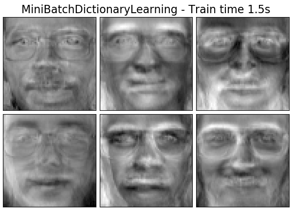

After using such a procedure to fit the dictionary, the transform is simply a sparse coding step that shares the same implementation with all dictionary learning objects (see Sparse coding with a precomputed dictionary).

It is also possible to constrain the dictionary and/or code to be positive to match constraints that may be present in the data. Below are the faces with different positivity constraints applied. Red indicates negative values, blue indicates positive values, and white represents zeros.

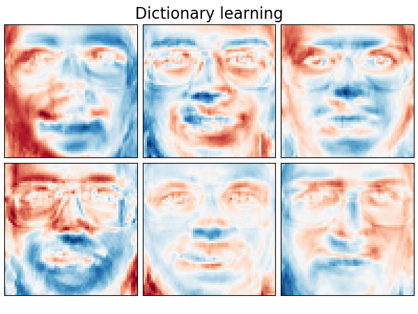

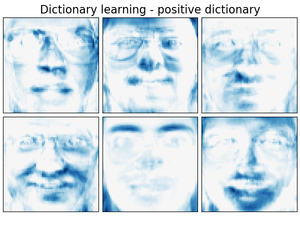

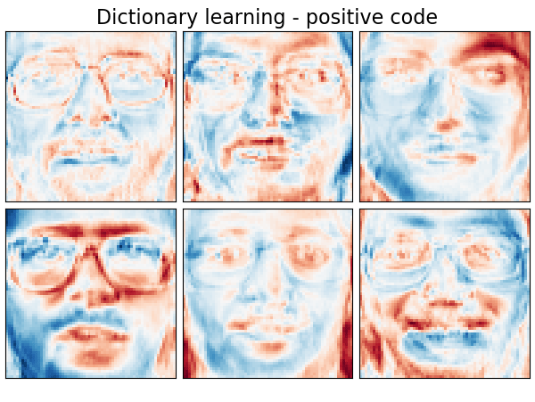

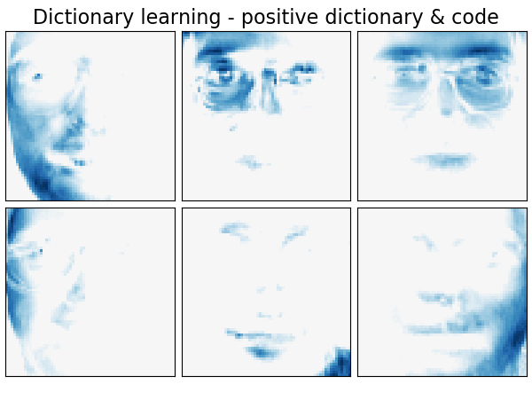

The following image shows how a dictionary learned from 4x4 pixel image patches extracted from part of the image of a raccoon face looks like.

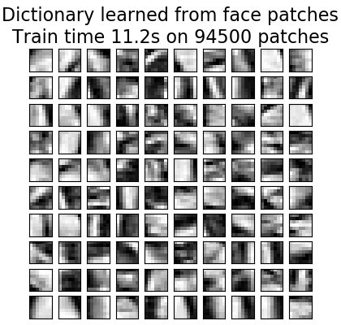

Examples:

- Image denoising using dictionary learning

References:

- [“Online dictionary learning for sparse coding”](http://www.di.ens.fr/sierra/pdfs/icml09.pdf) J. Mairal, F. Bach, J. Ponce, G. Sapiro, 2009

### 2.5.3.3. Mini-batch dictionary learning

`MiniBatchDictionaryLearning` implements a faster, but less accurate version of the dictionary learning algorithm that is better suited for large datasets.

By default, `MiniBatchDictionaryLearning` divides the data into mini-batches and optimizes in an online manner by cycling over the mini-batches for the specified number of iterations. However, at the moment it does not implement a stopping condition.

The estimator also implements `partial_fit`, which updates the dictionary by iterating only once over a mini-batch. This can be used for online learning when the data is not readily available from the start, or for when the data does not fit into the memory.

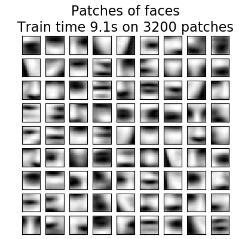

**Clustering for dictionary learning**

Note that when using dictionary learning to extract a representation (e.g. for sparse coding) clustering can be a good proxy to learn the dictionary. For instance the `MiniBatchKMeans` estimator is computationally efficient and implements on-line learning with a `partial_fit` method.

Example: Online learning of a dictionary of parts of faces

## 2.5.4. Factor Analysis

In unsupervised learning we only have a dataset $X = \{x_1, x_2, \dots, x_n \}$. How can this dataset be described mathematically? A very simple `continuous latent variable` model for $X$ is

$x_i = W h_i + \mu + \epsilon$

The vector $h_i$ is called “latent” because it is unobserved. $\epsilon$ is considered a noise term distributed according to a Gaussian with mean 0 and covariance $\Psi$ (i.e. $\epsilon \sim \mathcal{N}(0, \Psi)$), $\mu$ is some arbitrary offset vector. Such a model is called “generative” as it describes how $x_i$ is generated from $h_i$. If we use all the $x_i$‘s as columns to form a matrix $\mathbf{X}$ and all the $h_i$‘s as columns of a matrix $\mathbf{H}$ then we can write (with suitably defined $\mathbf{M}$ and $\mathbf{E}$):

$\mathbf{X} = W \mathbf{H} + \mathbf{M} + \mathbf{E}$

In other words, we *decomposed* matrix $\mathbf{X}$.

If $h_i$ is given, the above equation automatically implies the following probabilistic interpretation:

$p(x_i|h_i) = \mathcal{N}(Wh_i + \mu, \Psi)$

For a complete probabilistic model we also need a prior distribution for the latent variable $h$. The most straightforward assumption (based on the nice properties of the Gaussian distribution) is $h \sim \mathcal{N}(0, \mathbf{I})$. This yields a Gaussian as the marginal distribution of $x$:

$p(x) = \mathcal{N}(\mu, WW^T + \Psi)$

Now, without any further assumptions the idea of having a latent variable $h$ would be superfluous – $x$ can be completely modelled with a mean and a covariance. We need to impose some more specific structure on one of these two parameters. A simple additional assumption regards the structure of the error covariance $\Psi$:

- $\Psi = \sigma^2 \mathbf{I}$: This assumption leads to the probabilistic model of `PCA`.
- $\Psi = \mathrm{diag}(\psi_1, \psi_2, \dots, \psi_n)$: This model is called `FactorAnalysis`, a classical statistical model. The matrix W is sometimes called the “factor loading matrix”.

Both models essentially estimate a Gaussian with a low-rank covariance matrix. Because both models are probabilistic they can be integrated in more complex models, e.g. Mixture of Factor Analysers. One gets very different models (e.g. `FastICA`) if non-Gaussian priors on the latent variables are assumed.

Factor analysis *can* produce similar components (the columns of its loading matrix) to `PCA`. However, one can not make any general statements about these components (e.g. whether they are orthogonal):

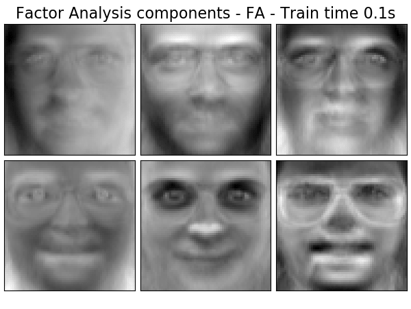

The main advantage for Factor Analysis over `PCA` is that it can model the variance in every direction of the input space independently (heteroscedastic noise):

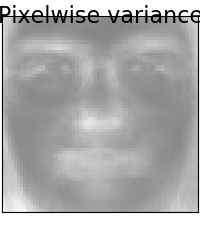

This allows better model selection than probabilistic PCA in the presence of heteroscedastic noise:

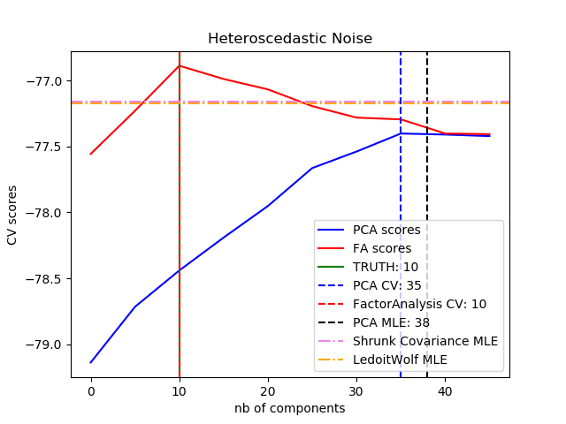

Examples:

- Model selection with Probabilistic PCA and Factor Analysis (FA)

## 2.5.5. Independent component analysis (ICA)

Independent component analysis separates a multivariate signal into additive subcomponents that are maximally independent. It is implemented in scikit-learn using the `Fast ICA` algorithm. Typically, ICA is not used for reducing dimensionality but for separating superimposed signals. Since the ICA model does not include a noise term, for the model to be correct, whitening must be applied. This can be done internally using the whiten argument or manually using one of the PCA variants.

It is classically used to separate mixed signals (a problem known as *blind source separation*), as in the example below:

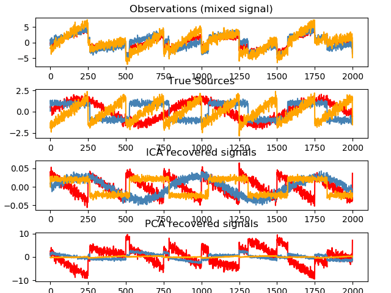

ICA can also be used as yet another non linear decomposition that finds components with some sparsity:

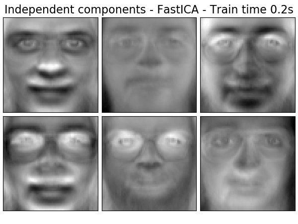

Examples:

- Blind source separation using FastICA
- FastICA on 2D point clouds
- Faces dataset decompositions

## 2.5.6. Non-negative matrix factorization (NMF or NNMF)

### 2.5.6.1. NMF with the Frobenius norm

`NMF` [1] is an alternative approach to decomposition that assumes that the data and the components are non-negative. `NMF` can be plugged in instead of `PCA` or its variants, in the cases where the data matrix does not contain negative values. It finds a decomposition of samples $X$ into two matrices $W$ and $H$ of non-negative elements, by optimizing the distance $d$ between $X$ and the matrix product $WH$. The most widely used distance function is the squared Frobenius norm, which is an obvious extension of the Euclidean norm to matrices:

$d_{\mathrm{Fro}}(X, Y) = \frac{1}{2} ||X - Y||_{\mathrm{Fro}}^2 = \frac{1}{2} \sum_{i,j} (X_{ij} - {Y}_{ij})^2$

Unlike `PCA`, the representation of a vector is obtained in an additive fashion, by superimposing the components, without subtracting. Such additive models are efficient for representing images and text.

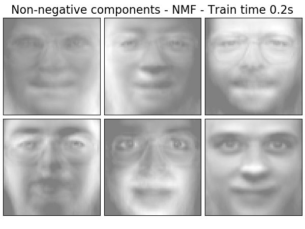

The `init` attribute determines the initialization method applied, which has a great impact on the performance of the method. `NMF` implements the method Nonnegative Double Singular Value Decomposition. NNDSVD [4] is based on two SVD processes, one approximating the data matrix, the other approximating positive sections of the resulting partial SVD factors utilizing an algebraic property of unit rank matrices. The basic NNDSVD algorithm is better fit for sparse factorization. Its variants NNDSVDa (in which all zeros are set equal to the mean of all elements of the data), and NNDSVDar (in which the zeros are set to random perturbations less than the mean of the data divided by 100) are recommended in the dense case.

Note that the Multiplicative Update (‘mu’) solver cannot update zeros present in the initialization, so it leads to poorer results when used jointly with the basic NNDSVD algorithm which introduces a lot of zeros; in this case, NNDSVDa or NNDSVDar should be preferred.

`NMF` can also be initialized with correctly scaled random non-negative matrices by setting `init="random"`. An integer seed or a `RandomState` can also be passed to `random_state` to control reproducibility.

In `NMF`, L1 and L2 priors can be added to the loss function in order to regularize the model. The L2 prior uses the Frobenius norm, while the L1 prior uses an elementwise L1 norm. As in `ElasticNet`, we control the combination of L1 and L2 with the `l1_ratio` ($\rho$) parameter, and the intensity of the regularization with the `alpha` ($\alpha$) parameter. Then the priors terms are:

$\alpha \rho ||W||_1 + \alpha \rho ||H||_1 + \frac{\alpha(1-\rho)}{2} ||W||_{\mathrm{Fro}} ^ 2 + \frac{\alpha(1-\rho)}{2} ||H||_{\mathrm{Fro}} ^ 2$

and the regularized objective function is:

$d_{\mathrm{Fro}}(X, WH) + \alpha \rho ||W||_1 + \alpha \rho ||H||_1 + \frac{\alpha(1-\rho)}{2} ||W||_{\mathrm{Fro}} ^ 2 + \frac{\alpha(1-\rho)}{2} ||H||_{\mathrm{Fro}} ^ 2$

`NMF` regularizes both W and H. The public function `non_negative_factorization` allows a finer control through the `regularization` attribute, and may regularize only W, only H, or both.

### 2.5.6.2. NMF with a beta-divergence

As described previously, the most widely used distance function is the squared Frobenius norm, which is an obvious extension of the Euclidean norm to matrices:

$d_{\mathrm{Fro}}(X, Y) = \frac{1}{2} ||X - Y||_{Fro}^2 = \frac{1}{2} \sum_{i,j} (X_{ij} - {Y}_{ij})^2$

Other distance functions can be used in NMF as, for example, the (generalized) Kullback-Leibler (KL) divergence, also referred as I-divergence:

$d_{KL}(X, Y) = \sum_{i,j} (X_{ij} \log(\frac{X_{ij}}{Y_{ij}}) - X_{ij} + Y_{ij})$

Or, the Itakura-Saito (IS) divergence:

$d_{IS}(X, Y) = \sum_{i,j} (\frac{X_{ij}}{Y_{ij}} - \log(\frac{X_{ij}}{Y_{ij}}) - 1)$

These three distances are special cases of the beta-divergence family, with $\beta = 2, 1, 0$ respectively [6]. The beta-divergence are defined by :

$d_{\beta}(X, Y) = \sum_{i,j} \frac{1}{\beta(\beta - 1)}(X_{ij}^\beta + (\beta-1)Y_{ij}^\beta - \beta X_{ij} Y_{ij}^{\beta - 1})$

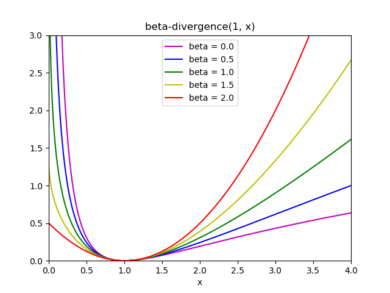

Note that this definition is not valid if $\beta \in (0; 1)$, yet it can be continuously extended to the definitions of $d_{KL}$ and $d_{IS}$ respectively.

`NMF` implements two solvers, using Coordinate Descent (‘cd’) [5], and Multiplicative Update (‘mu’) [6]. The ‘mu’ solver can optimize every beta-divergence, including of course the Frobenius norm ($\beta=2$), the (generalized) Kullback-Leibler divergence ($\beta=1$) and the Itakura-Saito divergence ($\beta=0$). Note that for $\beta \in (1; 2)$, the ‘mu’ solver is significantly faster than for other values of $\beta$. Note also that with a negative (or 0, i.e. ‘itakura-saito’) $\beta$, the input matrix cannot contain zero values.

The ‘cd’ solver can only optimize the Frobenius norm. Due to the underlying non-convexity of NMF, the different solvers may converge to different minima, even when optimizing the same distance function.

NMF is best used with the `fit_transform` method, which returns the matrix W. The matrix H is stored into the fitted model in the `components_` attribute; the method `transform` will decompose a new matrix X_new based on these stored components:

```
>>> import numpy as np
>>> X = np.array([[1, 1], [2, 1], [3, 1.2], [4, 1], [5, 0.8], [6, 1]])
>>> from sklearn.decomposition import NMF
>>> model = NMF(n_components=2, init='random', random_state=0)
>>> W = model.fit_transform(X)
>>> H = model.components_
>>> X_new = np.array([[1, 0], [1, 6.1], [1, 0], [1, 4], [3.2, 1], [0, 4]])
>>> W_new = model.transform(X_new)
```

Examples:

- Faces dataset decompositions
- Topic extraction with Non-negative Matrix Factorization and Latent Dirichlet Allocation
- Beta-divergence loss functions

References:

| [1] | [“Learning the parts of objects by non-negative matrix factorization”](http://www.columbia.edu/~jwp2128/Teaching/E4903/papers/nmf_nature.pdf) D. Lee, S. Seung, 1999 |
| --- | --- |

| [2] | [“Non-negative Matrix Factorization with Sparseness Constraints”](http://www.jmlr.org/papers/volume5/hoyer04a/hoyer04a.pdf) P. Hoyer, 2004 |
| --- | --- |

| [4] | [“SVD based initialization: A head start for nonnegative matrix factorization”](http://scgroup.hpclab.ceid.upatras.gr/faculty/stratis/Papers/HPCLAB020107.pdf) C. Boutsidis, E. Gallopoulos, 2008 |
| --- | --- |

| [5] | [“Fast local algorithms for large scale nonnegative matrix and tensor factorizations.”](http://www.bsp.brain.riken.jp/publications/2009/Cichocki-Phan-IEICE_col.pdf) A. Cichocki, A. Phan, 2009 |
| --- | --- |

| [6] | *(1, 2)* [“Algorithms for nonnegative matrix factorization with the beta-divergence”](https://arxiv.org/pdf/1010.1763.pdf) C. Fevotte, J. Idier, 2011 |
| --- | --- |

## 2.5.7. Latent Dirichlet Allocation (LDA)

Latent Dirichlet Allocation is a generative probabilistic model for collections of discrete dataset such as text corpora. It is also a topic model that is used for discovering abstract topics from a collection of documents.

The graphical model of LDA is a three-level Bayesian model:

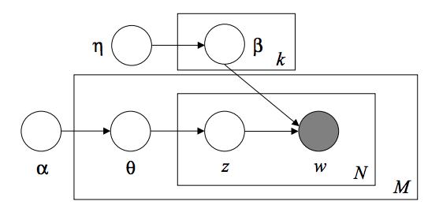

When modeling text corpora, the model assumes the following generative process for a corpus with $D$ documents and $K$ topics:

1. For each topic $k$, draw $\beta_k \sim \mathrm{Dirichlet}(\eta),\: k =1...K$
2. For each document $d$, draw $\theta_d \sim \mathrm{Dirichlet}(\alpha), \: d=1...D$
3. For each word $i$ in document $d$:
1. Draw a topic index $z_{di} \sim \mathrm{Multinomial}(\theta_d)$
2. Draw the observed word $w_{ij} \sim \mathrm{Multinomial}(\beta_{z_{di}})$

For parameter estimation, the posterior distribution is:

$p(z, \theta, \beta |w, \alpha, \eta) = \frac{p(z, \theta, \beta|\alpha, \eta)}{p(w|\alpha, \eta)}$

Since the posterior is intractable, variational Bayesian method uses a simpler distribution $q(z,\theta,\beta | \lambda, \phi, \gamma)$ to approximate it, and those variational parameters $\lambda$, $\phi$, $\gamma$ are optimized to maximize the Evidence Lower Bound (ELBO):

$\log\: P(w | \alpha, \eta) \geq L(w,\phi,\gamma,\lambda) \overset{\triangle}{=} E_{q}[\log\:p(w,z,\theta,\beta|\alpha,\eta)] - E_{q}[\log\:q(z, \theta, \beta)]$

Maximizing ELBO is equivalent to minimizing the Kullback-Leibler(KL) divergence between $q(z,\theta,\beta)$ and the true posterior $p(z, \theta, \beta |w, \alpha, \eta)$.

`LatentDirichletAllocation` implements online variational Bayes algorithm and supports both online and batch update method. While batch method updates variational variables after each full pass through the data, online method updates variational variables from mini-batch data points.

Note

Although online method is guaranteed to converge to a local optimum point, the quality of the optimum point and the speed of convergence may depend on mini-batch size and attributes related to learning rate setting.

When `LatentDirichletAllocation` is applied on a “document-term” matrix, the matrix will be decomposed into a “topic-term” matrix and a “document-topic” matrix. While “topic-term” matrix is stored as `components_` in the model, “document-topic” matrix can be calculated from `transform` method.

`LatentDirichletAllocation` also implements `partial_fit` method. This is used when data can be fetched sequentially.

Examples:

- Topic extraction with Non-negative Matrix Factorization and Latent Dirichlet Allocation

References:

- [“Latent Dirichlet Allocation”](http://www.jmlr.org/papers/volume3/blei03a/blei03a.pdf) D. Blei, A. Ng, M. Jordan, 2003
- [“Online Learning for Latent Dirichlet Allocation”](https://papers.nips.cc/paper/3902-online-learning-for-latent-dirichlet-allocation.pdf) M. Hoffman, D. Blei, F. Bach, 2010
- [“Stochastic Variational Inference”](http://www.columbia.edu/~jwp2128/Papers/HoffmanBleiWangPaisley2013.pdf) M. Hoffman, D. Blei, C. Wang, J. Paisley, 2013

© 2007–2018 The scikit-learn developers  
Licensed under the 3-clause BSD License.  
http://scikit-learn.org/stable/modules/decomposition.html